# act_report

## Report: act_report

- Create a **250-word-minimum written report** called "act_report.pdf" or "act_report.html" that communicates the insights and displays the visualization(s) produced from your wrangled data. This is to be framed as an external document, like a blog post or magazine article, for example.

WeRateDogs is a twitter account that provides expert dog ratings.

The account was created on Twitter in November 2015 and currently has over 9 million followers.

WeRateDogs granted Udacity access to their downloaded Twitter archive. As of August 1, 2017, this archive contains the fundamental twwet information (tweet ID, timestamp, source, text, etc.) for over 5000 tweets.

WeRateDogs granted Udacity access to their downloaded Twitter archive. As of August 1, 2017, this archive contains the fundamental twwet information (tweet ID, timestamp, source, text, etc.) for over 5000 tweets. Additional information was obtained using the Twitter API and picture prediction data. To obtain some understanding into the jumbled data, the data were collected, evaluated, cleansed, saved, analysed, and visualized. Let me walk you through some fascinating conclusions I came to from the data analysis.

most typical name given to dogs by people Different dog owners give their pets various names. Charlie is the most popular name on WeRateDogs, followed by Oliver and Penny. nice names, huh? I also adore the names.

Initial Dog published on the WeRateDogs page. Holly, the first dog listed on WeRateDogs, received a rating of 11/10. On November 30, 2015, a photo of the dog was uploaded online. The tweet was sent from an iPhone, and the dog has no nickname.

The chart below displays the most popular websites from which tweets were downloaded.

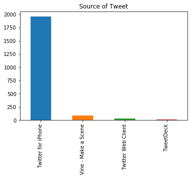

The chart below display smost common breed of dog predicted

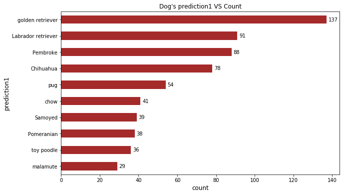

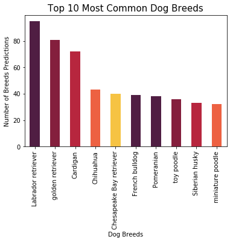

[figure not shown]